# Assignment #8

Anna Ehrhorn

April 4, 2020

*The assignment is focusing on our continued learning of knowledge and skills* *related to function developmental and application, and Geoms.*

### Question 1

This is a function that will create an extra column to sum total score of a likert score while accounting for revere scored items.

Required within the function are the following:

- Data frame with rows indicating individuals and columns indicating items.
- A numeric indicating the scale used for the items.
- A numeric vector to indicate which items to be revered scored when summing scores to calculate the total score.

```r
surv.tot.score <- function(my.surv.data, scale.num, vector.num){
  # Changing to a matrix
  matrix.surv.data <- as.matrix(my.surv.data)

  # reverse scoring
  matrix.surv.data[,vector.num] <- (scale.num + 1) - matrix.surv.data[,vector.num]

  # sum of rows using a vector function
  sum.tot.score <- rowSums(matrix.surv.data)

  # Add on column of sum.tot.score to original dataframe
  my.surv.data$sum <- sum.tot.score

  return(my.surv.data)
}
```

### Question 2

```r
write.csv(complete.survey.data2, here("Data", "Survey Data Complete.csv"))
```

[output not shown]

### Question 3

Constructing a single scatter plot showing the relationship of science scores to math scores by gender using hsb2 data and ggplot.

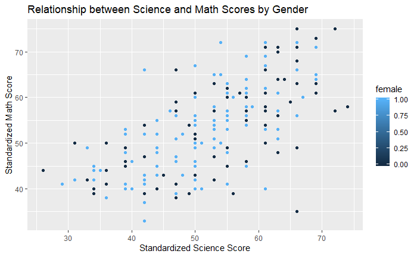

```r
ggplot(data = hsb2) +
  geom_point(mapping = aes(x = science, y = math, color = female)) +
  labs(x = "Standardized Science Score", y = "Standardized Math Score",
  title = "Relationship between Science and Math Scores by Gender")
```

### Question 4

This scatterplot is showing the same relationship, but with each gender with a seperate scatterplot.

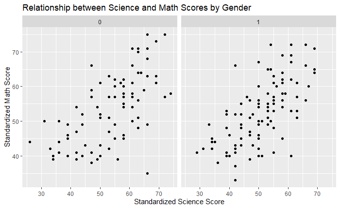

```r
ggplot(data = hsb2) +
  geom_point(mapping = aes(x = science, y = math)) +
  labs(x = "Standardized Science Score", y = "Standardized Math Score",
  title = "Relationship between Science and Math Scores by Gender") +
  facet_grid( ~ female)
```

### Question 5

A graph created using the *geom_boxplot* to illustrate math scores for each socioeconomic status level.

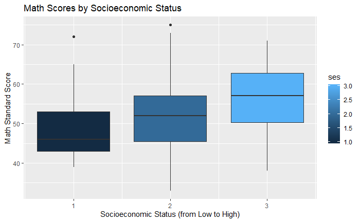

```r
ggplot(data = hsb2) +
  geom_boxplot(mapping = aes(x = ses, y = math, fill = ses, group = ses)) +
  labs(x = "Socioeconomic Status (from Low to High)", y = "Math Standard Score",
  title = "Math Scores by Socioeconomic Status")
```